# “Introduction to Statistics for Data Science I_Part2”

p_new_h

2020 11 16

# 데이터사이언스를 위한 통계학입문 I

## 2. 데이터 과학과 통계 - 빅데이터 탐색의 첫걸음

### 2-1. 빅데이터 탐색의 첫걸음 - 데이터의 평균(중심위치)

- 평균은 요약된 정보 : 평균은 데이터를 **하나의 값** 으로 표현한 요약된 정보 **(추정치)!**
- 전과목의 평균 = (국어점수 + 수학점수 +…+ 국사점수)/9 (과목수)
- 네덜란드 성인남자 평균키 = 네덜란드 성인남자들 키 총합 / 조사대상자 수
- **평균 = 데이터 값의 총 합 / 데이터 개수**

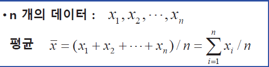

- 평균은 **혼자 존재하는 개념**이 아니다!

### 평균을 다룰 때 주의할 점 - 평균과 표본산정

- 어떻게 **표본선정을 하느냐**에 따라 평균값에 영향을 미친다.  
  ex) 대기업의 평균연봉을 알아보기 위해 표본 200명을 선정

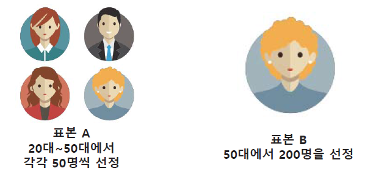

- 조사된 평균값이 **모집단을 대표하는 통계치라고 할 수 있나?**
- 표본이 적합하게 추출되었는지 평가하는 방법(평균을 예제로 하면)

[figure not shown]

  - 1. 편의가(Bias)가 적은가? : 표본을 추출할 때 표본으로부터 얻어지는 통계치(표본평균)의 기대값이 모수의 참값과 유사한가?
  - 2. 정확도(Precision)가 높은가? : 반복해서 표본을 추출할 때 (반복 실험할 때) 얼마나 유사한 값들이 나오는 가?